# nb_11_Salifort_Motors_project_Model_Comparisons

EDA Cleanse - .ipynb EDA Analysis - .ipynb Feature Engineering - .ipynb

**ML Models**

**Client Documentation**

*menu* Menu

# Salifort Motors - ML Models Comparisons

### Document Information

| Document Title | Salifort Motors - ML Modelling - Random Forest |
| --- | --- |
| Author | Rod Slater |
| Version | 1.0 |
| Created | 01-11-2023 |
| Modified | 16-11-2023 |

### Client Details

| Client Name | Salifort Motors |
| --- | --- |
| Client Contact | Mr HR Team |
| Client Email | hr@salifortmotors.it |
| Client Project | HR Team Data Driven Solutions from Machine Learning Models |

### Document Overview

Comparisons of the three ML Models developed : Random Forest, Decision Tree and XGBoost.

### Notes

Models have been pickle saved

- Salifort Motors - ML Models Comparisons
  - Document Information
  - Client Details
  - Document Overview
  - Notes
  - Initialise Notebook
    - Import Packages
    - Set Pandas Options
    - Initialise Notebook Options
    - Define Functions
      - display_results() - Function to retrieve scores from Results.csv and display them
      - Read / Write Pickle Function
  - Model Performance
    - Import data
    - Code flags:
    - Prepare data for SHAP Plots
    - Shap Plots for feature importance
  - Get previous models results data
    - Conclusion

## Initialise Notebook

### Import Packages

```python
# Import packages

# Data manipulation
import numpy as np
import pandas as pd

# Data visualization
import matplotlib.pyplot as plt
import matplotlib.image as mpimg
import seaborn as sns

# Set Options
pd.set_option('display.max_columns', None)

# Data modelling Imports
from xgboost import XGBClassifier, XGBRegressor, plot_importance

from sklearn.linear_model import LogisticRegression
from sklearn.tree import DecisionTreeClassifier
from sklearn.ensemble import RandomForestClassifier

# For metrics and helpful functions
from sklearn.model_selection import GridSearchCV, train_test_split
from sklearn.metrics import accuracy_score, precision_score, recall_score, precision_recall_fscore_support, \
f1_score, confusion_matrix, ConfusionMatrixDisplay, classification_report
from sklearn import metrics
from sklearn.metrics import roc_auc_score, roc_curve
from sklearn.tree import plot_tree
from sklearn.preprocessing import StandardScaler
from datetime import datetime as dt

import statsmodels.api as sm

# For saving models
import pickle

import shap
```

### Set Pandas Options

```python
# set Pandas Display Options
pd.options.display.float_format = '{:.2f}'.format
#pd.set_option('display.precision', 2)
pd.set_option('display.max_columns', None)
pd.set_option('display.width', 120)
```

```python
# Add a little colour

class color:
   PURPLE = '\033[95m'
   CYAN = '\033[96m'
   DARKCYAN = '\033[36m'
   BLUE = '\033[94m'
   GREEN = '\033[92m'
   YELLOW = '\033[93m'
   RED = '\033[91m'
   BOLD = '\033[1m'
   UNDERLINE = '\033[4m'
   END = '\033[0m'
```

### Initialise Notebook Options

```python
load_path = "/home/hass/Documents/Learning/Salifort-Motors-Capstone-Project/00-data_cleaned/" # Source folder for cleaned data
#save_path = "/home/hass/Documents/Learning/Salifort-Motors-Capstone-Project/04-pickle-ML-models/" # destination for pickle saved models

model_path = "/home/hass/Documents/Learning/Salifort-Motors-Capstone-Project/04-pickle-ML-models/" # path to load/save pickled models
```

### Define Functions

#### display_results() - Function to retrieve scores from Results.csv and display them

```python
def display_results():
    '''
    Load Results.csv containing store test scores, return the scores for display
    In: none
    Out: pandas df of Results,csv containing precision, recall, f1, accuracy, and AUC scores of the models
    '''
    model_results = pd.read_csv("Results.csv")
    model_results.drop(columns=['Unnamed: 0'], inplace=True)
    model_results = model_results.sort_values(by='AUC', ascending=False)

    return model_results
```

#### Read / Write Pickle Function

- write_pickle = Write the model
- read_pickle = Read the model

```python
def write_pickle(path, model_object, save_as:str):
    '''
    In:
        path:         path of folder where you want to save the pickle
        model_object: a model you want to pickle
        save_as:      filename for how you want to save the model

    Out: A call to pickle the model in the folder indicated
    '''

    with open(path + save_as + '.pickle', 'wb') as to_write:
        pickle.dump(model_object, to_write)

def read_pickle(path, saved_model_name:str):
    '''
    In:
        path:             path to folder where you want to read from
        saved_model_name: filename of pickled model you want to read in

    Out:
        model: the pickled model
    '''
    with open(path + saved_model_name + '.pickle', 'rb') as to_read:
        model = pickle.load(to_read)

    return model
```

## Model Performance

### Import data

Two datasets for model performance comparison, :

- `data_cleaned_NoOl_FE_AllFeat.csv` (THIS DATA) is the full data set feature engineered with `salary` encoded to ordinal, `avg_mth_hrs` binary encoded to `overwork` and dept encoded with dummies
- `data_cleaned_NoOl_FE_NoDept.csv` is the same data with the dummy encoded dept fields removed.

`Dept` appears to have low correlation across the dataset and I'm curious how much the models are influenced with low correlation features. It turns out that low correlation features have little impact on model performance. which is no surprise really!

### Code flags:

**rerun** = flag to identify the first run of the model comparisons and write a NEW Results.csv file. 0 = first run and a new file will be created with headers / 1 = Continuation, Results will be appended to the file.

**dataset** = Text indicating which dataset is being used, added to the model description during csv save to Results.csv

**model_prefix** = text indicating which ML model is being used, added to the model description during csv save to Results.csv

**refit** = Random Forest fits with this data takes 20-30 mins. 1 = Fit Data and Pickle Save Model 0 = don't refit data, Pickle load model

**fitver** = suffix added to pickle save model file name to help distinguish rf1/rf2 and all feature or focus features datasets

```python
# Load cleaned dataset into a dataframe
print("Started / Last Run =", dt.now().strftime("%Y-%m-%d %H:%M:%S"),"\n")

# Feature engineering on salary, avg_mnth_hrs, dept, outliers removed, all features
AllFeat_df = pd.read_csv(load_path + "data_cleaned_NoOl_FE_AllFeat.csv", index_col = False)
AllFeat_df.sort_index(axis = 1, inplace=True)

# Feature engineering - departments removed
NoDept_df = pd.read_csv(load_path + "data_cleaned_NoOl_FE_NoDept.csv", index_col = False)
NoDept_df.sort_index(axis = 1, inplace=True)
```

```
Started / Last Run = 2023-12-01 09:25:03
```

### Prepare data for SHAP Plots

```python
# List of models to pickle load
model_list = ['hr_dt1-AllFeat', 'hr_dt2-NOdept',
              'hr_rf1-AllFeat','hr_rf2-NOdept',
              'hr_xg1-AllFeat','hr_xg2-NOdept']

# List of dataframes to iterate
data_list  = ['AllFeat_df', 'NoDept_df',
              'AllFeat_df', 'NoDept_df',
              'AllFeat_df', 'NoDept_df']

# List of titles for the shap plots
model_name = ['Decision Tree - All Features', 'Decision Tree - No Departments',
              'Random Forest - All Features','Random Forest- No Departments',
              'XGBoost - All Features', 'XGBoost - No Departments']
```

### Shap Plots for feature importance

```
Decision Tree - All Features - hr_dt1-AllFeat
Predict will leave (True)  : 0.936
Predict will stay (True)  : 0.987
```

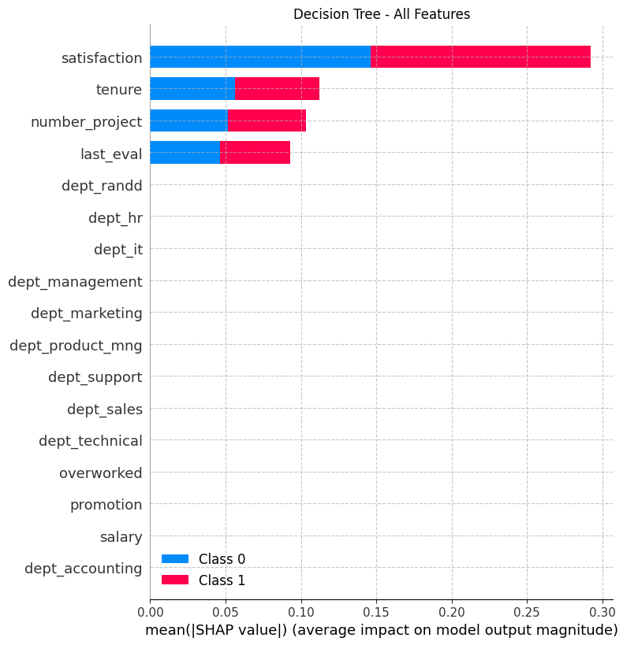

```
Decision Tree - No Departments - hr_dt2-NOdept
Predict will leave (True)  : 0.936
Predict will stay (True)  : 0.987
```

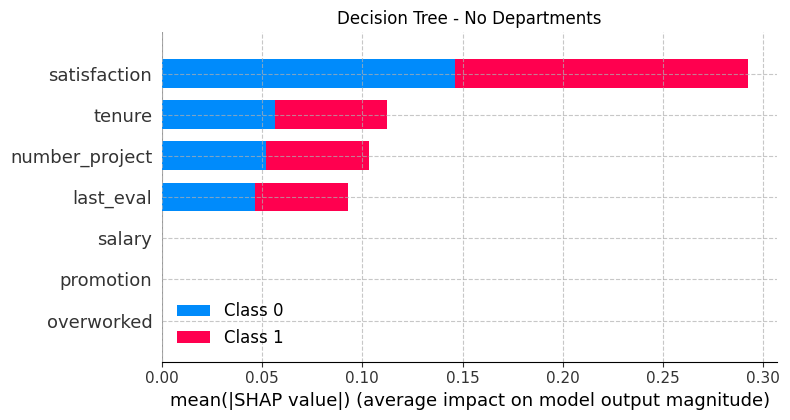

```
Random Forest - All Features - hr_rf1-AllFeat
Predict will leave (True)  : 0.943
Predict will stay (True)  : 0.989
```

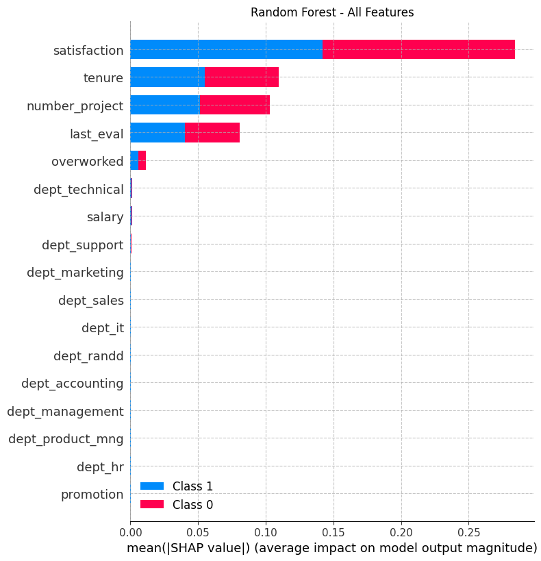

```
Random Forest- No Departments - hr_rf2-NOdept
Predict will leave (True)  : 0.943
Predict will stay (True)  : 0.989
```

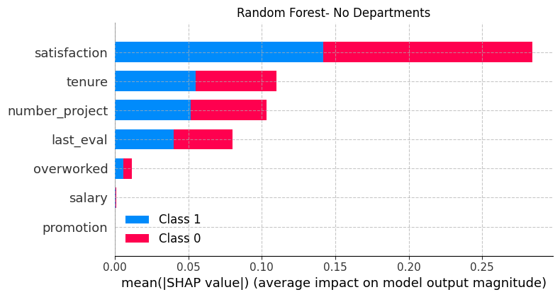

```
XGBoost - All Features - hr_xg1-AllFeat
Predict will leave (True)  : 0.938
Predict will stay (True)  : 0.988
```

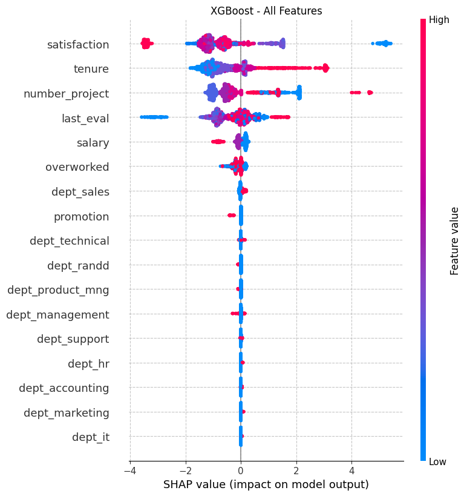

```
XGBoost - No Departments - hr_xg2-NOdept
Predict will leave (True)  : 0.942
Predict will stay (True)  : 0.988
```

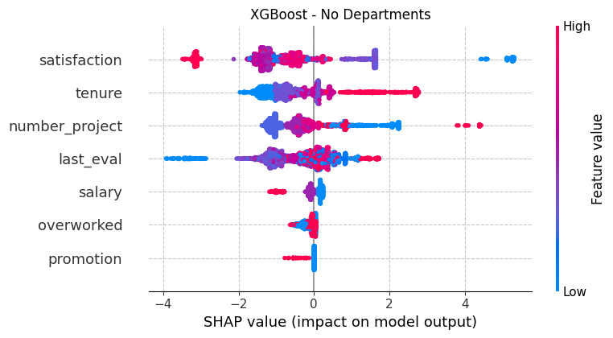

```python
import warnings

warnings.filterwarnings("ignore")

for i in range(len(model_list)):
    model_file = model_list[i]
    model_data = globals()[data_list[i]].copy()
    model_title = model_name[i]

    # Isolate the outcome variable
    y = model_data['left']

    # Select & Isolate the feature variables and drop the outcome variable
    X = model_data.copy()
    X = X.drop('left', axis = 1)

    # Prepare training and test data
    X_train, X_test, y_train, y_test = train_test_split(X,y, test_size=0.25, stratify=y, random_state=0)

    #model_file = model_list[0]
    model = read_pickle(model_path, model_file)
    print(color.BOLD + model_title + " - " + model_file + color.END)
    best_model = model.best_estimator_ # Store best model parameters for later testing

    y_pred_test = best_model.predict(X_test)

    explainer = shap.TreeExplainer(best_model)

    # Calculate SHAP values for a specific observation
    shap_values = explainer.shap_values(X_test)

    #shap_values = shap_values[..., 1]


    predict_precision, predict_recall, predict_f1_score, _ = precision_recall_fscore_support(y_test, y_pred_test, average=None)
    f1_true_class = round(predict_f1_score[1],3)  # Index 1 corresponds to the "True" class
    f1_false_class = round(predict_f1_score[0],3)  # Index o corresponds to the "False" class

# Plot the SHAP values for that observation
    print("Predict will leave (True)  : {}".format(f1_true_class))
    print("Predict will stay (True)  : {}\n".format(f1_false_class))
    plt.title(model_title)
    plt.grid(True, linestyle='--', alpha=0.7)
    shap.summary_plot(shap_values, X_test)

    #shap.plots.waterfall(shap_values)
```

## Get previous models results data

```python
pd.options.display.float_format = '{:.4f}'.format
results_df = display_results()
results_df
```

|  | Model | Precision | Recall | F1 | Accuracy | AUC | Predict Leave | Predict Stay |
| --- | --- | --- | --- | --- | --- | --- | --- | --- |
| 12 | rf1 - ALLFeat - train | 0.9799 | 0.9801 | 0.9798 | 0.9801 | 0.9874 | 0.9390 | 0.9881 |
| 15 | rf2 - NOdept - train | 0.9799 | 0.9801 | 0.9798 | 0.9801 | 0.9873 | 0.9390 | 0.9881 |
| 18 | xg1 - ALLFeat - train | 0.9797 | 0.9798 | 0.9796 | 0.9798 | 0.9870 | 0.9386 | 0.9879 |
| 17 | xg1 - ALLFeat - test | 0.9791 | 0.9792 | 0.9791 | 0.9792 | 0.9860 | 0.9376 | 0.9875 |
| 22 | xg2 - NOdept - train | 0.9803 | 0.9804 | 0.9802 | 0.9804 | 0.9854 | 0.9404 | 0.9883 |
| 20 | xg2 - NOdept - train | 0.9803 | 0.9804 | 0.9802 | 0.9804 | 0.9854 | 0.9404 | 0.9883 |
| 14 | rf2 - NOdept - test | 0.9809 | 0.9810 | 0.9809 | 0.9810 | 0.9833 | 0.9426 | 0.9886 |
| 21 | xg2 - NOdept - test | 0.9805 | 0.9807 | 0.9805 | 0.9807 | 0.9833 | 0.9418 | 0.9884 |
| 23 | xg2 - NOdept - test | 0.9805 | 0.9807 | 0.9805 | 0.9807 | 0.9833 | 0.9418 | 0.9884 |
| 11 | rf1 - ALLFeat - test | 0.9809 | 0.9810 | 0.9809 | 0.9810 | 0.9832 | 0.9426 | 0.9886 |
| 16 | xg1 - ALLFeat - GS train | 0.9570 | 0.9100 | 0.9330 | 0.9780 | 0.9820 | NaN | NaN |
| 19 | xg2 - NOdept - GS train | 0.9600 | 0.9130 | 0.9360 | 0.9790 | 0.9810 | NaN | NaN |
| 13 | rf2 - NOdept - GS train | 0.9639 | 0.9086 | 0.9354 | 0.9789 | 0.9808 | NaN | NaN |
| 10 | rf1 - ALLFeat - GS train | 0.9638 | 0.9079 | 0.9350 | 0.9787 | 0.9802 | NaN | NaN |
| 8 | dt2 - NOdept - test | 0.9784 | 0.9785 | 0.9785 | 0.9785 | 0.9791 | 0.9359 | 0.9871 |
| 5 | dt1 - ALLFeat - test | 0.9784 | 0.9785 | 0.9785 | 0.9785 | 0.9791 | 0.9359 | 0.9871 |
| 9 | dt2 - NOdept - train | 0.9784 | 0.9786 | 0.9784 | 0.9786 | 0.9789 | 0.9352 | 0.9872 |
| 6 | dt1 - ALLFeat - train | 0.9784 | 0.9786 | 0.9784 | 0.9786 | 0.9789 | 0.9352 | 0.9872 |
| 7 | dt2 - NOdept - GS train | 0.9506 | 0.9135 | 0.9317 | 0.9774 | 0.9737 | NaN | NaN |
| 4 | dt1 - ALLFeat - GS train | 0.9506 | 0.9135 | 0.9317 | 0.9774 | 0.9737 | NaN | NaN |
| 1 | lr1 - ALLFeat - train | 0.7737 | 0.8130 | 0.7860 | 0.8130 | 0.8867 | 0.2578 | 0.8930 |
| 3 | lr2 - NOdept - train | 0.7702 | 0.8111 | 0.7833 | 0.8111 | 0.8860 | 0.2467 | 0.8920 |
| 2 | lr2 - NOdept - test | 0.7670 | 0.8062 | 0.7806 | 0.8062 | 0.8783 | 0.2476 | 0.8888 |
| 0 | lr1 - ALLFeat - test | 0.7760 | 0.8112 | 0.7878 | 0.8112 | 0.8781 | 0.2771 | 0.8915 |

```python
results_test_df = results_df[results_df['Model'].str.contains('test')]
results_test_df
```

|  | Model | Precision | Recall | F1 | Accuracy | AUC | Predict Leave | Predict Stay |
| --- | --- | --- | --- | --- | --- | --- | --- | --- |
| 17 | xg1 - ALLFeat - test | 0.9791 | 0.9792 | 0.9791 | 0.9792 | 0.9860 | 0.9376 | 0.9875 |
| 14 | rf2 - NOdept - test | 0.9809 | 0.9810 | 0.9809 | 0.9810 | 0.9833 | 0.9426 | 0.9886 |
| 21 | xg2 - NOdept - test | 0.9805 | 0.9807 | 0.9805 | 0.9807 | 0.9833 | 0.9418 | 0.9884 |
| 23 | xg2 - NOdept - test | 0.9805 | 0.9807 | 0.9805 | 0.9807 | 0.9833 | 0.9418 | 0.9884 |
| 11 | rf1 - ALLFeat - test | 0.9809 | 0.9810 | 0.9809 | 0.9810 | 0.9832 | 0.9426 | 0.9886 |
| 8 | dt2 - NOdept - test | 0.9784 | 0.9785 | 0.9785 | 0.9785 | 0.9791 | 0.9359 | 0.9871 |
| 5 | dt1 - ALLFeat - test | 0.9784 | 0.9785 | 0.9785 | 0.9785 | 0.9791 | 0.9359 | 0.9871 |
| 2 | lr2 - NOdept - test | 0.7670 | 0.8062 | 0.7806 | 0.8062 | 0.8783 | 0.2476 | 0.8888 |
| 0 | lr1 - ALLFeat - test | 0.7760 | 0.8112 | 0.7878 | 0.8112 | 0.8781 | 0.2771 | 0.8915 |

[figure not shown]

```python
plt.figure(figsize=(10, 6))
sns.barplot(x='Model', y='AUC', hue='AUC', data=results_test_df, palette='colorblind')
plt.xlabel('Model')
plt.ylabel('AUC')
plt.title('Model Comparison test data')
plt.ylim(0.75, 1)  # Set y-axis range between 0 and 1
plt.legend(title='AUC Score')
plt.xticks(rotation='vertical')
plt.show()
```

```python
import warnings
pd.options.display.float_format = '{:.4f}'.format

warnings.filterwarnings("ignore")

for i in range(6):
    model_file = model_list[i]
    model_data = globals()[data_list[i]].copy()
    model_title = model_name[i]

    # Isolate the outcome variable
    Y = model_data['left']

    # Select & Isolate the feature variables and drop the outcome variable
    X = model_data.copy()
    X = X.drop('left', axis = 1)

    # Prepare training and test data
    X_train, X_test, y_train, y_test = train_test_split(X,Y, test_size=0.25, stratify=Y, random_state=0)

    #model_file = model_list[0]
    model = read_pickle(model_path, model_file)
    print(color.BOLD + model_title + " - " + model_file + color.END)
    best_model = model.best_estimator_ # Store best model parameters for later testing

    y_pred_test = best_model.predict(X_train)

#    explainer = shap.TreeExplainer(best_model)

    # Calculate SHAP values for a specific observation
#    shap_values = explainer.shap_values(X_train)

    #shap_values = shap_values[..., 1]


    predict_precision, predict_recall, predict_f1_score, _ = precision_recall_fscore_support(y_train, y_pred_test, average=None)
    f1_true_class = predict_f1_score[1]  # Index 1 corresponds to the "True" class
    f1_false_class = predict_f1_score[0]  # Index o corresponds to the "False" class


    print("Predict will leave (True)  : {:.4%}".format(f1_true_class))
    print("Predict will stay (False)  : {:.4%}\n".format(f1_false_class))
```

```
Decision Tree - All Features - hr_dt1-AllFeat
Predict will leave (True)  : 93.5215%
Predict will stay (False)  : 98.7202%

Decision Tree - No Departments - hr_dt2-NOdept
Predict will leave (True)  : 93.5215%
Predict will stay (False)  : 98.7202%

Random Forest - All Features - hr_rf1-AllFeat
Predict will leave (True)  : 93.9029%
Predict will stay (False)  : 98.8081%

Random Forest- No Departments - hr_rf2-NOdept
Predict will leave (True)  : 93.9029%
Predict will stay (False)  : 98.8081%

XGBoost - All Features - hr_xg1-AllFeat
Predict will leave (True)  : 93.8568%
Predict will stay (False)  : 98.7928%

XGBoost - No Departments - hr_xg2-NOdept
Predict will leave (True)  : 94.0407%
Predict will stay (False)  : 98.8284%
```

## Comparing ROC and Precision-Recall across models

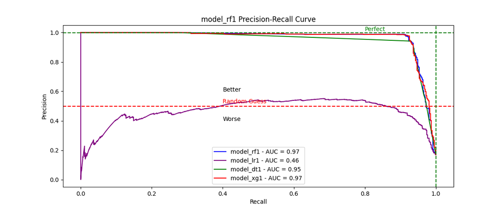

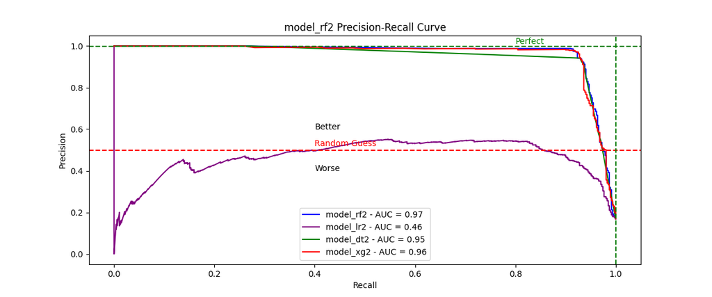

[figure not shown]

[figure not shown]

```python
from PIL import Image
plots = ['./99-documentation-project/08-plot_data/plot-pr-curve1.png',
         './99-documentation-project/08-plot_data/plot-pr-curve2.png',
         './99-documentation-project/08-plot_data/plot-roc-curve1.png',
         './99-documentation-project/08-plot_data/plot-roc-curve2.png']

image_path = './99-documentation-project/08-plot_data/plot-pr-curve1.png'

for plot in plots:
    img = Image.open(plot)
    display(img)
```

### Conclusion

The best performing models are RandomForest and XGBoost.

There's not a great deal of difference between Random Forest and XGBoost.

Removing features to simplify the model, doesn't appear to make a significant difference in smaller datasets, although I would imagine it makes a larger computational time difference for larger datasets.

I'll proceed with the demonstration model using XGBoost, but will also compare predictions across the three main models.